# Multi Ski Pass Exploratory Analysis

Winston Saunders

June 20, 2015

# 1 Summary

This analysis looks at data on skier chairlift rides. A few sample skier “days” for multiple seasons (05-06 to 14-15) are used to draw general conclusions about the capability of modeling in enhancing prediction of skier visits and chair lift rides.

The analysis provides potential benefit to three groups: 1. Area-management. Predictive models provide skier load anlaysis allowing better management of hill-side resources. Details of chair loading can be correlated to date, day, and time, weather conditions, snow conditions, etc. 2. Management and Users: Models can detect fraudulent pass use, protecting purchasers and area managment from fraud. 3. Area-users: Analytics can provide insights to skiers on their performance and possibly enable marketing and other offers to tailor and optimize their on-hill and off-hill experience.

The purpose is to explore the feasiblity and reliability with which skier visits can be predicted and analyzed for the benefit of the hill operator.

A secondary purpose is to provide advanced analystics to individual skiers and explore whether “fraud” (that is the use of a ski pass by other than the owner) can be detected from this data.

Key findings include:  
1. Skier behavior is remarkably reproducile on a day to day basis.

# 2 Data Structure

All ski runs data for a sample of individual skiers are documented. Note that this sample is much smaller than the total data available to the ski lift operator (who in principle has it all).

## 2.1 Raw Data

Just to give a flavor for the data, here is a sample of ski runs for an individual skier. Note the sample spans multiple years.

| time | chair | vertical_feet | vertical_meters | year | month | day | time_of_day | date | pass |
| --- | --- | --- | --- | --- | --- | --- | --- | --- | --- |
| 2014-04-11 14:20:04 | Summit | 1709 | 520 | 2014 | 4 | 11 | 14:20:04 | 2014-04-11 | 7b410007 |
| 2014-04-11 13:16:36 | Summit | 1709 | 520 | 2014 | 4 | 11 | 13:16:36 | 2014-04-11 | 7b410007 |
| 2014-04-11 12:09:55 | Pine Marten | 1367 | 416 | 2014 | 4 | 11 | 12:09:55 | 2014-04-11 | 7b410007 |
| 2013-04-12 12:08:23 | Summit | 1709 | 520 | 2013 | 4 | 12 | 12:08:23 | 2013-04-12 | 7b410007 |
| 2013-04-09 11:45:30 | Northwest | 2377 | 724 | 2013 | 4 | 9 | 11:45:30 | 2013-04-09 | 7b410007 |
| 2013-04-09 09:19:08 | Pine Marten | 1367 | 416 | 2013 | 4 | 9 | 09:19:08 | 2013-04-09 | 7b410007 |
| 2012-04-24 09:19:28 | Pine Marten | 1367 | 416 | 2012 | 4 | 24 | 09:19:28 | 2012-04-24 | 7b410007 |
| 2011-04-10 13:04:16 | Pine Marten | 1367 | 416 | 2011 | 4 | 10 | 13:04:16 | 2011-04-10 | 7b410007 |
| 2010-04-12 13:43:37 | Pine Marten | 1367 | 416 | 2010 | 4 | 12 | 13:43:37 | 2010-04-12 | 7b410007 |

## 2.2 Summarized for daily data

Each skier makes a few dozen to several hundred runs per season. A way to meaningfully summarize the data is to first read in all the data and looks at total number of days skied.

### 2.2.1 14-15

Here’s a representation of the skiers per day for the 14-15 Season.

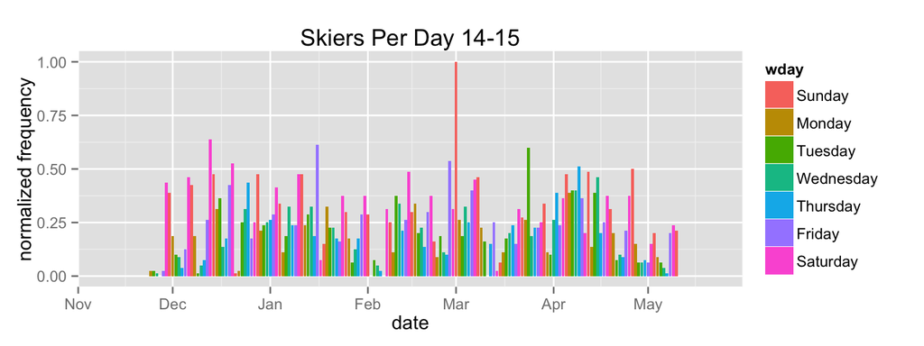

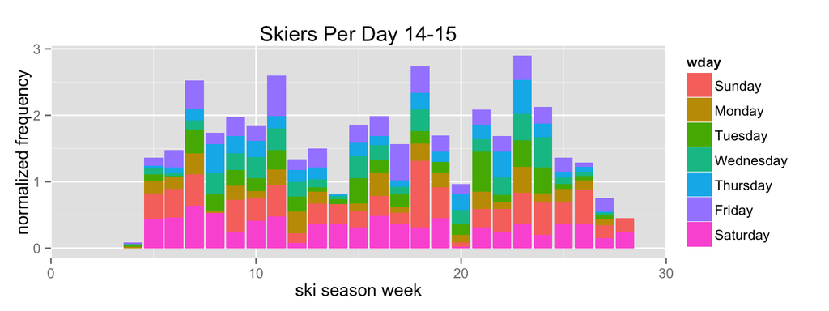

```r
    print(head(skier_day_count_14_15))
```

```
##      all_ski_days Freq week yday season_week     wday year season
## 1799   2015-03-01   80    9   59          18   Sunday 2015  14-15
## 1723   2014-12-13   51   50  346           7 Saturday 2014  14-15
## 1757   2015-01-16   49    3   15          11   Friday 2015  14-15
## 1821   2015-03-24   48   12   82          21  Tuesday 2015  14-15
## 1797   2015-02-27   43    9   57          17   Friday 2015  14-15
## 1730   2014-12-20   42   51  353           8 Saturday 2014  14-15
##      normal_Freq skier_cum
## 1799      1.0000    1.0000
## 1723      0.6375    1.6375
## 1757      0.6125    2.2500
## 1821      0.6000    2.8500
## 1797      0.5375    3.3875
## 1730      0.5250    3.9125
```

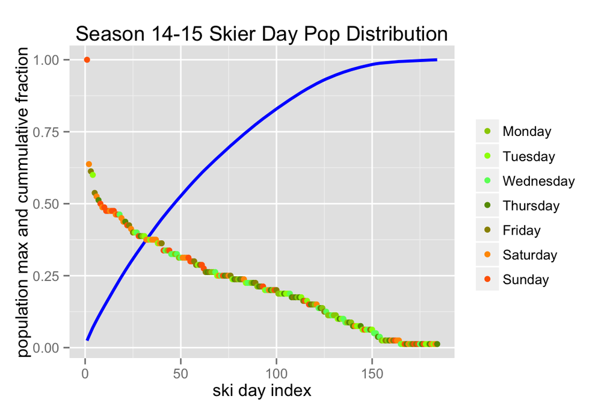

### 2.2.2 12-13 Season Comparison

Here’s a representation of the skiers per day for the 12-13 Season.

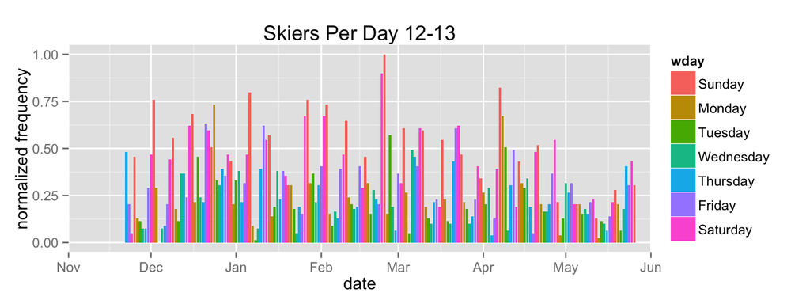

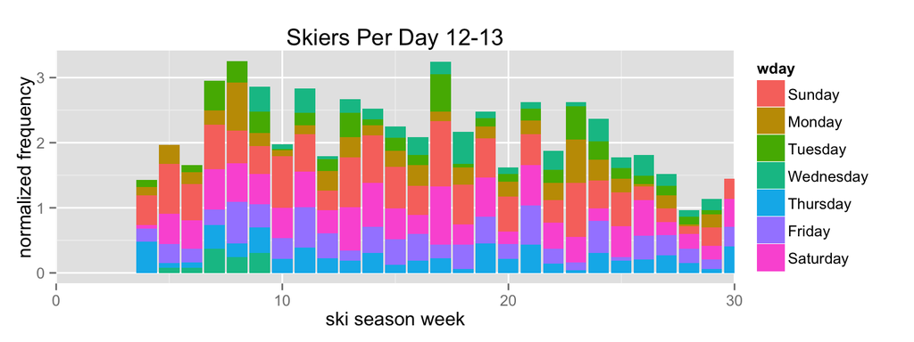

```r
    print(head(skier_day_count_12_13))
```

```
##      all_ski_days Freq week yday season_week     wday year season
## 1419   2013-02-24   79    8   54          17   Sunday 2013  12-13
## 1418   2013-02-23   71    8   53          17 Saturday 2013  12-13
## 1461   2013-04-07   65   14   96          23   Sunday 2013  12-13
## 1370   2013-01-06   63    1    5          10   Sunday 2013  12-13
## 1336   2012-12-02   60   49  336           5   Sunday 2012  12-13
## 1391   2013-01-27   60    4   26          13   Sunday 2013  12-13
##      normal_Freq skier_cum
## 1419   1.0000000  1.000000
## 1418   0.8987342  1.898734
## 1461   0.8227848  2.721519
## 1370   0.7974684  3.518987
## 1336   0.7594937  4.278481
## 1391   0.7594937  5.037975
```

[output not shown]

[output cut: 27 more lines]

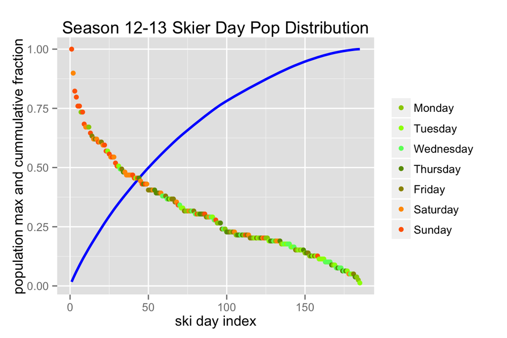

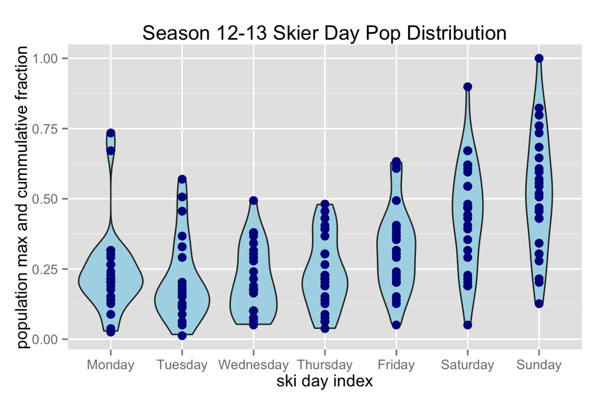

### 2.2.3 12-13 Season

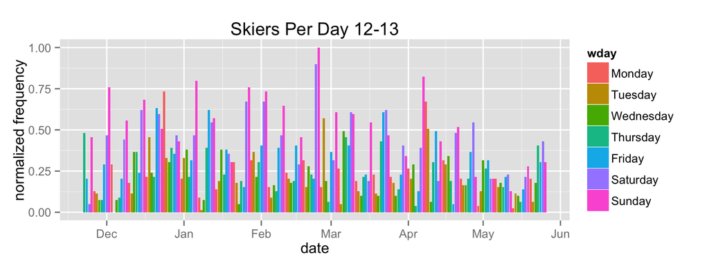

Next, let’s explore looking at daily total runs and vertical feet.

### 2.2.4 Totals Runs Per Day

Here is a sample of the data for total runs per day per skier.

| runs_per_day | date | pass | week | season_week | wday | year | weekend | holiday | bizday | season |
| --- | --- | --- | --- | --- | --- | --- | --- | --- | --- | --- |
| 14.00 | 2013-03-06 | ec34001e | 10 | 14.00 | 3 | 2013 | FALSE | FALSE | TRUE | 12-13 |
| 18.00 | 2012-12-16 | dc6e8366 | 51 | 3.00 | 0 | 2012 | TRUE | TRUE | FALSE | 12-13 |
| 4.00 | 2011-05-28 | dc6e8366 | 22 | 26.00 | 6 | 2011 | TRUE | TRUE | FALSE | 10-11 |
| 5.00 | 2014-02-09 | c36bc572 | 6 | 11.00 | 0 | 2014 | TRUE | TRUE | FALSE | 13-14 |
| 9.00 | 2011-12-19 | 22f3ebd1 | 51 | 3.00 | 1 | 2011 | FALSE | FALSE | TRUE | 11-12 |
| 19.00 | 2008-02-16 | 22f3ebd1 | 7 | 12.00 | 6 | 2008 | TRUE | TRUE | FALSE | 07-08 |
| 19.00 | 2012-03-14 | cf87f389 | 11 | 15.00 | 3 | 2012 | FALSE | FALSE | TRUE | 11-12 |
| 3.00 | 2011-02-14 | 9e9db4ff | 7 | 11.00 | 1 | 2011 | FALSE | FALSE | TRUE | 10-11 |
| 12.00 | 2007-12-17 | 9e9db4ff | 51 | 3.00 | 1 | 2007 | FALSE | FALSE | TRUE | 07-08 |

From random sample of data from 23 out of the 348 skiers a graph below show that runs per skier are fairly consistent from season to season.

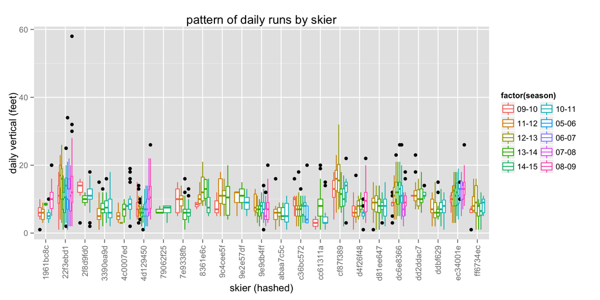

### 2.2.5 Total Vertical Feet Per Day

We can also look at the number of vertical feet skied per day per skier. Again, most skiers seem to demonstrate fairly consistent behavior.

[output not shown]

A random sample of 8 of the current 348 skiers is used. Below are the first few rows of the data. (NOTE - PASS NUMBERS HAVE BEEN HASHED TO PRESERVE ANONYMITY)

There appears to be pretty good distinction between individual skiers. We can also check the data from season to season as below. Again, it appears to provide a reasonably consistent picture.

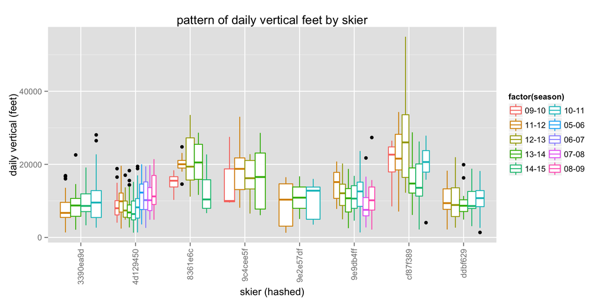

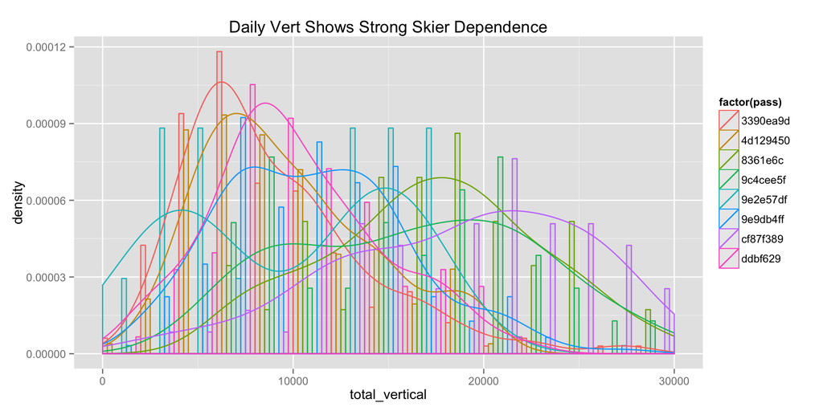

# 3 Skier Speed Analytics

To analyze skier speed we need to add some more data. While the pass data tracks the vertical rise of the chairlift ride, the descent, which is the actual skiing part, is to the base of the next chairlift. Base elevations are not supplied with the downloaded data so need to be added. We can get some more data from the [Master Development Plan](http://www.mtbachelor.com/site/about_us/company_info/forest_service/MDP_Text.pdf)

So let’s look at ski speed to see if more related to a skier or to a ski run.  
Calculated ski times that are below the chairlift ride time result in “negative” speeds and are anomalous. It will be worth looking at these in more detail, because they appear to occur for some users and not others. In some cases it appears that riders may have checked in to, say Summit, but then decided to ski a different lift. In the graph below ski speeds are shown as distributions for weekends/holidays and weekdays.

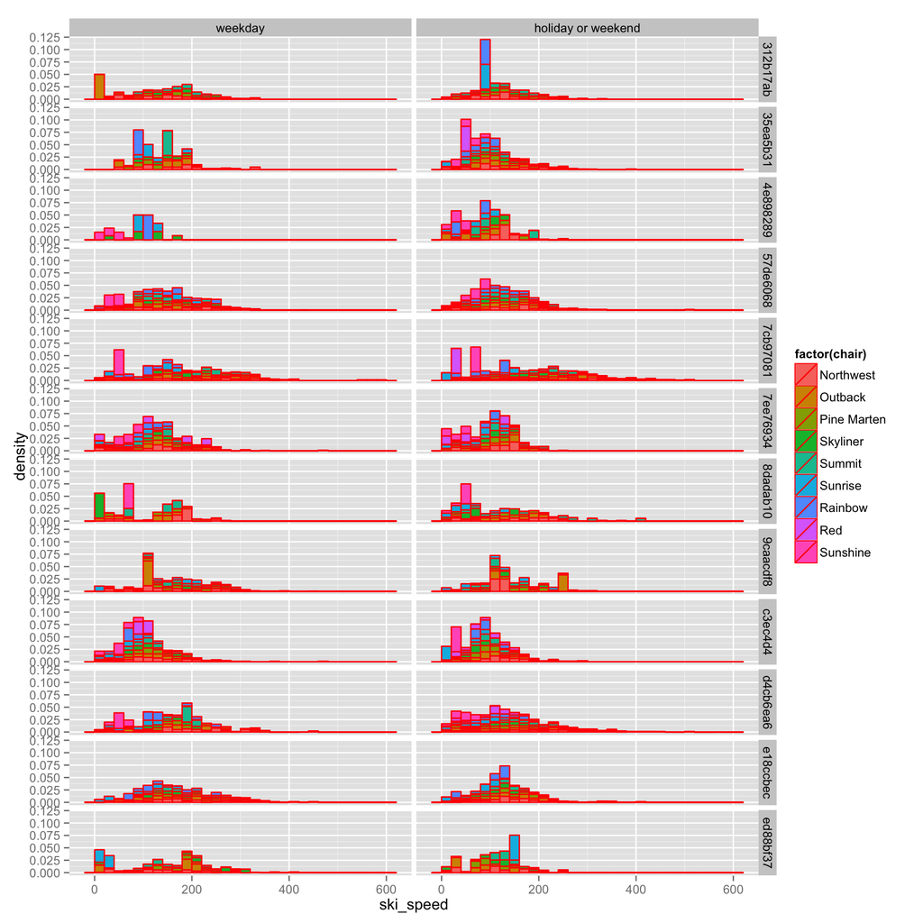

With this insight we can look at the velocity statistics of individual skiers on specific chair lifts.

# 4 Chairlift Choice

Another preference individual skiers have is for specific chairlifts. Let’s see if this can contribute to behavioral classification. To do this we’ll adopt a simple model of unigram maximum likelhood estimators. Here are the frequencies of charlift rides for a sample of skiers.

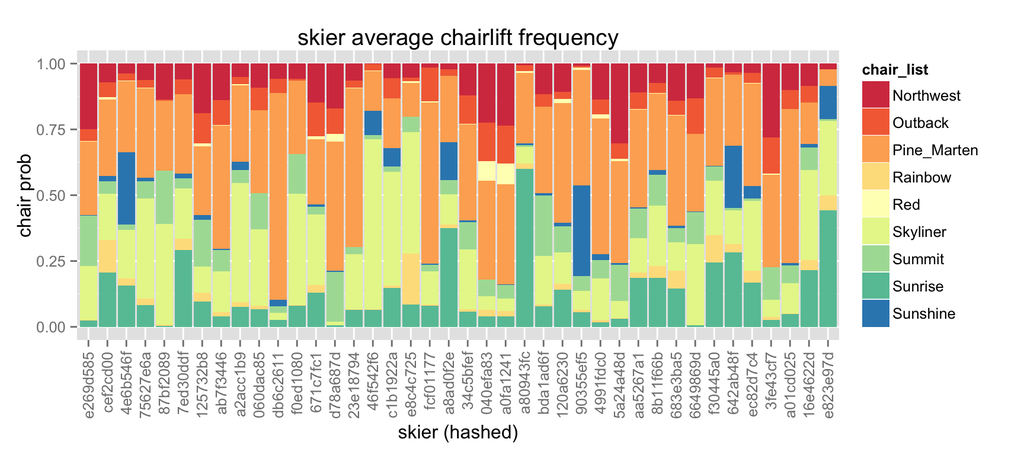

As can be seen there are strong variations in the choice of chairlifts between skiers.

## 4.1 MLE for Ski days

The approach will be to take the averaged probabilities and use the MLE’s for a single skier to calculate the expected probability for each ski day for a large sample of skiers.  
Here is a sample of skier probabilities (expressed as logarithms) for a specific passholder.

| chair_list | aa5267a1 |
| --- | --- |
| Sunrise | -0.73 |
| Rainbow | -1.69 |
| Skyliner | -0.88 |
| Summit | -0.95 |
| Sunshine | -2.46 |
| Pine_Marten | -0.43 |
| Red | -2.53 |
| Outback | -1.21 |
| Northwest | -0.96 |

The table above shows the probabilities for aa5267a1. We can use the same lookup methodology.

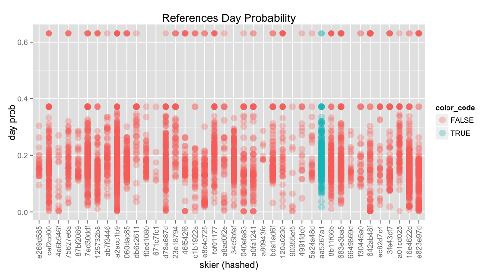

Here are some sample probabilities

| date | pass | day_prob |
| --- | --- | --- |
| 2008-12-15 | aa5267a1 | -0.43 |
| 2008-12-17 | aa5267a1 | -0.43 |
| 2008-12-19 | aa5267a1 | -0.73 |
| 2009-01-10 | aa5267a1 | -0.53 |
| 2009-01-12 | aa5267a1 | -0.84 |
| 2009-01-14 | aa5267a1 | -0.70 |
| 2009-01-15 | aa5267a1 | -0.65 |
| 2009-01-16 | aa5267a1 | -0.61 |
| 2009-01-22 | aa5267a1 | -0.67 |
| 2009-01-23 | aa5267a1 | -0.64 |

```
##            date     pass   day_prob color_code
## 3022 2008-12-15 aa5267a1 -0.4292973       TRUE
## 3023 2008-12-17 aa5267a1 -0.4292973       TRUE
## 3024 2008-12-19 aa5267a1 -0.7312717       TRUE
## 3025 2009-01-10 aa5267a1 -0.5298894       TRUE
## 3026 2009-01-12 aa5267a1 -0.8375462       TRUE
## 3027 2009-01-14 aa5267a1 -0.7044045       TRUE
```

## 4.2 Days of the Week